# Tutorial 3 - Poisson Regression ROC

# Library

```r
library(glm2)
library(pROC)
library(ggplot2)
library(lmtest)
library(broom)
library(glmulti)
library(magrittr)
library(dplyr)
library(tidyverse)
library(glue)
#library(plotROC)
#library(precrec)
```

# Challenger Data

```r
# Create dataframe for Challenger accident data
ca <- data.frame("Temp"=c(53,56,57,63,66,67,67,67,68,69,70,70,
                          70,70,72,73,75,75,76,76,78,79,80,81),
                 "Failure"=c(rep(1,3),rep(0,8),rep(1,3),rep(0,3),1,rep(0,6)))
ca
```

| Temp | Failure |
| --- | --- |
| 53 | 1 |
| 56 | 1 |
| 57 | 1 |
| 63 | 0 |
| 66 | 0 |
| 67 | 0 |
| 67 | 0 |
| 67 | 0 |
| 68 | 0 |
| 69 | 0 |

[output cut: 14 more lines]

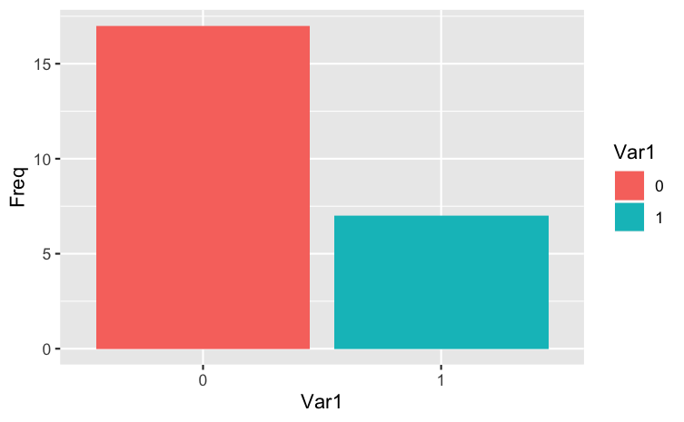

```r
ggplot(data.frame(table(ca$Failure)), aes(x=Var1, y=Freq, fill=Var1)) + geom_bar(stat="identity", position="dodge")
```

## Logistic Regression

```r
fit <- glm2(Failure~Temp, data = ca, family = "binomial")
summary(fit)
```

```
Call:
glm2(formula = Failure ~ Temp, family = "binomial", data = ca)

Deviance Residuals:
    Min       1Q   Median       3Q      Max
-1.2125  -0.8253  -0.4706   0.5907   2.0512

Coefficients:
            Estimate Std. Error z value Pr(>|z|)
(Intercept) 10.87535    5.70291   1.907   0.0565 .
Temp        -0.17132    0.08344  -2.053   0.0400 *
---
Signif. codes:  0 ‘***’ 0.001 ‘**’ 0.01 ‘*’ 0.05 ‘.’ 0.1 ‘ ’ 1

(Dispersion parameter for binomial family taken to be 1)

    Null deviance: 28.975  on 23  degrees of freedom
Residual deviance: 23.030  on 22  degrees of freedom
AIC: 27.03

Number of Fisher Scoring iterations: 4
```

### Fitted Probabilities

```r
ca$predicted <- predict(fit, type = "response")
ca
```

| Temp | Failure | predicted |
| --- | --- | --- |
| 53 | 1 | 0.85758349 |
| 56 | 1 | 0.78268818 |
| 57 | 1 | 0.75214414 |
| 63 | 0 | 0.52052785 |
| 66 | 0 | 0.39369565 |
| 67 | 0 | 0.35362920 |
| 67 | 0 | 0.35362920 |
| 67 | 0 | 0.35362920 |
| 68 | 0 | 0.31551837 |
| 69 | 0 | 0.27973723 |

[output cut: 14 more lines]

We can always set threshold and see Sensitiviy ans Specificity

## ROC Curve

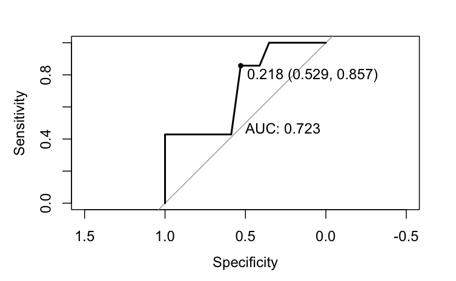

```r
roccurve <- roc(ca$Failure~ca$predicted)
plot.roc(roccurve, print.auc = TRUE, print.thres = "best", print.thres.best.method = "closest.topleft")
```

**Insights**

- Best cut-off is `c = 0.218` which gives us Specificity of 0.529 and Sensitivity of 0.857.
- Trade off between Specificity and Sensitivity
- AUC is 0.723
- Not always we choose the shoulder / “optimum” point. Depends on use case. If suicide, then want to find all true positive, maybe we want sensitivity (TPR) to be higher.

# Cancer Data

```r
ovarian <- read.csv("/Users/jasonchan/MSTAT/STAT6014_Advanced_Stat_Model/Tutorial codes/Tutorial3/ovarian.csv")
ovarian
```

| alb | tp | totscore | popind |
| --- | --- | --- | --- |
| 3.0 | 5.8 | 10 | 0 |
| 3.2 | 5.8 | 3 | 1 |
| 3.8 | 5.7 | 5 | 1 |
| 4.1 | 6.6 | 5 | 1 |
| 2.3 | 4.4 | 6 | 1 |
| 3.8 | 6.8 | 7 | 1 |
| 3.1 | 6.6 | 6 | 1 |
| 3.2 | 5.1 | 5 | 1 |
| 3.7 | 6.1 | 5 | 1 |
| 2.9 | 5.7 | 9 | 0 |

[output cut: 33 more lines]

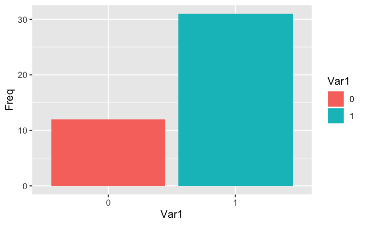

```r
ggplot(data.frame(table(ovarian$popind)), aes(x=Var1, y=Freq, fill=Var1)) + geom_bar(stat="identity", position="dodge")
```

## Fit 4 Logistic Regression Models

```r
# fit logistic regression models
fitfull <- glm2(popind~alb+tp+totscore, family = binomial, data = ovarian)
fitalb <- glm2(popind~alb, family = binomial, data = ovarian)
fittp <- glm2(popind~tp, family = binomial, data = ovarian)
fitts <- glm2(popind~totscore, family = binomial, data = ovarian)

# compute fitted probabilities
fullpred <- predict(fitfull, type = "response")
albpred <- predict(fitalb, type = "response")
tppred <- predict(fittp, type = "response")
tspred <- predict(fitts, type = "response")
```

## ROC Plot

```r
# generate ROC objects
rocfull <- roc(ovarian$popind~fullpred)
rocalb <- roc(ovarian$popind~albpred)
roctp <- roc(ovarian$popind~tppred)
rocts <- roc(ovarian$popind~tspred)
# plot overlaid ROC curves with AUC
plot.roc(rocfull)
plot.roc(rocalb, add = TRUE, col='red')
```

```r
plot.roc(roctp, add = TRUE, col='blue')
plot.roc(rocts, add = TRUE, col='green')
```

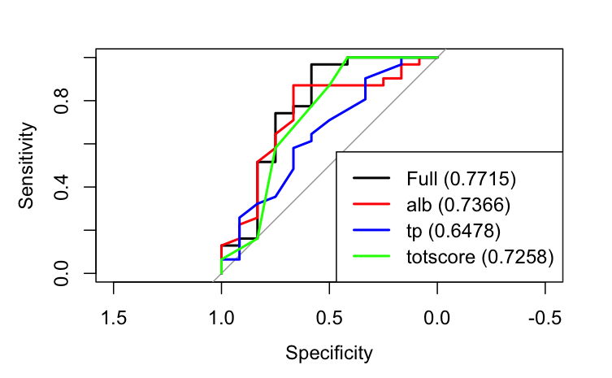

```r
lfull <- paste0("Full (",round(auc(rocfull),4),")")
lalb <- paste0("alb (",round(auc(rocalb),4),")")
ltp <- paste0("tp (",round(auc(roctp),4),")")
lts <- paste0("totscore (",round(auc(rocts),4),")")
legend("bottomright", legend=c(lfull, lalb, ltp, lts),
       col=c("black", "red", "blue", "green"), lwd=2)
```

- Is red (alb) or green (totscore) **significantly different** from the full model? If not, then we can consider picking them too.

## ROC Test

```r
# Compare each model with full model using AUC tests
albtest <- roc.test(rocalb,rocfull)
tptest <- roc.test(roctp,rocfull)
tstest <- roc.test(rocts,rocfull)
Estimate = c(albtest$estimate[1]-albtest$estimate[2],
             tptest$estimate[1]-tptest$estimate[2],
             tstest$estimate[1]-tstest$estimate[2])
p_value = c(albtest$p.value, tptest$p.value, tstest$p.value)
tests <- data.frame(Estimate, p_value)
row.names(tests) <- c("Albumin - Full Model", "Total Protein - Full Model",
                      "K-G Score - Full Model")
tests
```

|  | Estimate | p_value |
| --- | --- | --- |
| Albumin - Full Model | -0.03494624 | 0.5453739 |
| Total Protein - Full Model | -0.12365591 | 0.0933236 |
| K-G Score - Full Model | -0.04569892 | 0.4151692 |

- Turns out red and green is not statistically significant from Full Model
- Can consider choosing them too

# Q1: Poisson Regression

- Often use log-link as the link function

```r
# Create AIDS deaths dataset
death <- data.frame(x = 1:14,
                    y = c(0,1,2,3,1,4,9,18,23,31,20,25,37,45))

death
```

| x | y |
| --- | --- |
| 1 | 0 |
| 2 | 1 |
| 3 | 2 |
| 4 | 3 |
| 5 | 1 |
| 6 | 4 |
| 7 | 9 |
| 8 | 18 |
| 9 | 23 |
| 10 | 31 |

[output cut: 4 more lines]

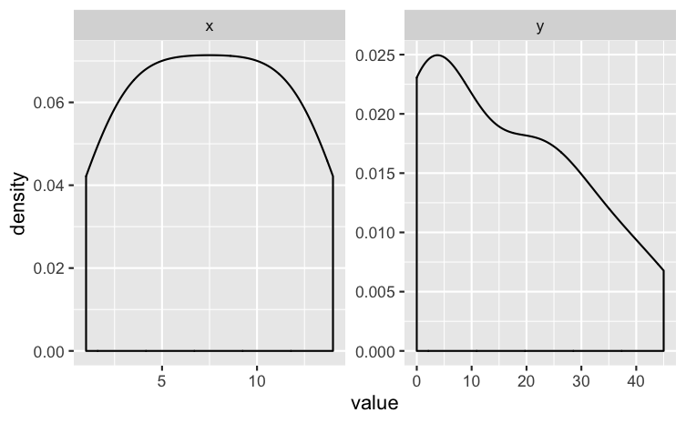

```r
death %>%
  keep(is.numeric) %>%                     # Keep only numeric columns
  gather() %>%                             # Convert to key-value pairs
  ggplot(aes(value)) +                     # Plot the values
    facet_wrap(~ key, scales = "free") +   # In separate panels
    geom_density()                         # as density
```

```r
glue("Mean: {mean(death$y)}, SD: {sd(death$y)}")
```

```
Mean: 15.6428571428571, SD: 14.9851574918299
```

## Q1(a)

```r
fit1a.1 <- glm2(y~x, data = death, family = "poisson"(link="log"))
summary(fit1a.1)
```

```
Call:
glm2(formula = y ~ x, family = poisson(link = "log"), data = death)

Deviance Residuals:
     Min        1Q    Median        3Q       Max
-2.21008  -1.02032  -0.69704   0.04028   2.70758

Coefficients:
            Estimate Std. Error z value Pr(>|z|)
(Intercept)  0.33963    0.25119   1.352    0.176
x            0.25652    0.02204  11.639   <2e-16 ***
---
Signif. codes:  0 ‘***’ 0.001 ‘**’ 0.01 ‘*’ 0.05 ‘.’ 0.1 ‘ ’ 1

(Dispersion parameter for poisson family taken to be 1)

    Null deviance: 207.272  on 13  degrees of freedom
Residual deviance:  29.654  on 12  degrees of freedom
AIC: 86.581

Number of Fisher Scoring iterations: 5
```

```r
fit1a.2 <- glm2(y~log(x), data = death, family = "poisson"(link="log"))
summary(fit1a.2)
```

```
Call:
glm2(formula = y ~ log(x), family = poisson(link = "log"), data = death)

Deviance Residuals:
     Min        1Q    Median        3Q       Max
-2.08992  -1.07141  -0.04657   0.38956   1.94311

Coefficients:
            Estimate Std. Error z value Pr(>|z|)
(Intercept)  -1.9442     0.5116   -3.80 0.000145 ***
log(x)        2.1748     0.2150   10.11  < 2e-16 ***
---
Signif. codes:  0 ‘***’ 0.001 ‘**’ 0.01 ‘*’ 0.05 ‘.’ 0.1 ‘ ’ 1

(Dispersion parameter for poisson family taken to be 1)

    Null deviance: 207.272  on 13  degrees of freedom
Residual deviance:  17.092  on 12  degrees of freedom
AIC: 74.019

Number of Fisher Scoring iterations: 4
```

### Model (i) and (ii) Comparison

```r
loglikelihood <- c(logLik(fit1a.1), logLik(fit1a.2))
AIC <- c(aic(fit1a.1), aic(fit1a.2))
BIC <- c(bic(fit1a.1), bic(fit1a.2))
dispersion <- c(fit1a.1$deviance/fit1a.1$df.residual,
                fit1a.2$deviance/fit1a.2$df.residual)
gof.1a <- cbind(loglikelihood, AIC, BIC, dispersion)
row.names(gof.1a) <- c("Model (i)", "Model (ii)")
gof.1a
```

```
           loglikelihood      AIC      BIC dispersion
Model (i)      -41.29035 86.58070 87.85882   2.471127
Model (ii)     -35.00942 74.01884 75.29696   1.424305
```

- Get the estimated mu, $\hat{\mu} = exp(\alpha + \beta(log(x)))$

```r
mu <- exp(-1.9442 + 2.1748*log(6)) ; mu
```

```
[1] 7.046412
```

```r
# P(Y <= 5 | X = 6)
# Calculate estimated probability using Poisson cdf
ppois(5, lambda = mu)
```

```
[1] 0.2948201
```

# Horse Shoe Crab Data

```r
# Read Horseshoe Crabs dataset
crab <- read.csv(file = "/Users/jasonchan/MSTAT/STAT6014_Advanced_Stat_Model/Tutorial codes/Tutorial3/crab.csv", header = TRUE)

crab
```

| Obs | T | C | W | N |
| --- | --- | --- | --- | --- |
| 1 | 15.9 | 28.3 | 3.05 | 8 |
| 2 | 18.1 | 26.0 | 2.60 | 4 |
| 3 | 15.1 | 25.6 | 2.15 | 0 |
| 4 | 20.5 | 21.0 | 1.85 | 0 |
| 5 | 18.1 | 29.0 | 3.00 | 1 |
| 6 | 18.0 | 25.0 | 2.30 | 3 |
| 7 | 15.2 | 26.2 | 1.30 | 0 |
| 8 | 22.4 | 24.9 | 2.10 | 0 |
| 9 | 20.3 | 25.7 | 2.00 | 8 |
| 10 | 19.1 | 27.5 | 3.15 | 6 |

[output cut: 163 more lines]

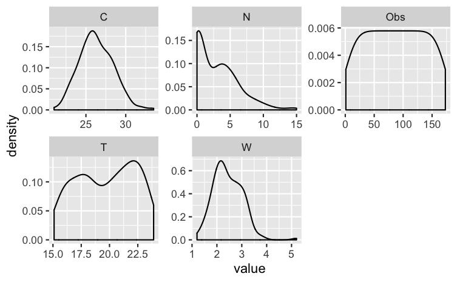

```r
crab %>%
  keep(is.numeric) %>%                     # Keep only numeric columns
  gather() %>%                             # Convert to key-value pairs
  ggplot(aes(value)) +                     # Plot the values
    facet_wrap(~ key, scales = "free") +   # In separate panels
    geom_density()
```

```r
glue("Mean: {mean(crab$N)}, SD: {sd(crab$N)}")
```

```
Mean: 2.91907514450867, SD: 3.14833571023175
```

## Using `glmulti` to fit all possible combinations

```r
# Alternative - use glmulti function to fit all subset models
fit2a <- glmulti(N ~ T + C + W, family = poisson,
                level = 1, method = "h", data = crab, crit = "aic")
```

```
Initialization...
TASK: Exhaustive screening of candidate set.
Fitting...
Completed.
```

```r
print(fit2a)
```

[output not shown]

```r
weightable(fit2a)
```

| model | aic | weights |
| --- | --- | --- |
| N ~ 1 + W | 920.1405 | 4.090471e-01 |
| N ~ 1 + C + W | 921.1829 | 2.428977e-01 |
| N ~ 1 + T + W | 921.5190 | 2.053238e-01 |
| N ~ 1 + T + C + W | 922.5236 | 1.242437e-01 |
| N ~ 1 + C | 927.1762 | 1.213319e-02 |
| N ~ 1 + T + C | 928.4698 | 6.354582e-03 |
| N ~ 1 | 990.0893 | 2.645889e-16 |
| N ~ 1 + T | 991.7963 | 1.126966e-16 |

```r
fit2a@objects[[1]]
```

```
Call:  fitfunc(formula = as.formula(x), family = ..1, data = data)

Coefficients:
(Intercept)            W
    -0.4282       0.5892

Degrees of Freedom: 172 Total (i.e. Null);  171 Residual
Null Deviance:      632.8
Residual Deviance: 560.8    AIC: 920.1
```

- Hence, best model is $log(\hat{\mu}) = -0.4282 + 0.5892W$

```r
glue("for 1 increase in unit of W, there is a {round(exp(0.5892) -1 , 3)} increase in the mean satelitties ")
```

```
for 1 increase in unit of W, there is a 0.803 increase in the mean satelitties
```

## Using `glm2`

```r
model <- c("N ~ T",
           "N ~ C",
           "N ~ W",
           "N ~ T + C",
           "N ~ T + W",
           "N ~ C + W",
           "N ~ T + C + W")

loglikelihood = AIC = BIC = deviance = dispersion = NULL
fit <- vector(mode = "list", length = length(model))
for (i in 1:length(model)) {
   fit[[i]] <- glm2(model[i], family = poisson, data = crab)
   loglikelihood <- c(loglikelihood, logLik(fit[[i]]))
   AIC <- c(AIC, aic(fit[[i]]))
   BIC <- c(BIC, bic(fit[[i]]))
   deviance <- c(deviance, fit[[i]]$deviance)
   dispersion <- c(dispersion, fit[[i]]$deviance/fit[[i]]$df.residual)
}

gof.2a <- cbind(loglikelihood, AIC, BIC, deviance, dispersion)
row.names(gof.2a) <- model
gof.2a <- data.frame(gof.2a)
```

```r
round(gof.2a[order(gof.2a$AIC), ], 2)
```

|  | loglikelihood | AIC | BIC | deviance | dispersion |
| --- | --- | --- | --- | --- | --- |
| N ~ W | -458.07 | 920.14 | 926.45 | 560.84 | 3.28 |
| N ~ C + W | -457.59 | 921.18 | 930.64 | 559.89 | 3.29 |
| N ~ T + W | -457.76 | 921.52 | 930.98 | 560.22 | 3.30 |
| N ~ T + C + W | -457.26 | 922.52 | 935.14 | 559.23 | 3.31 |
| N ~ C | -461.59 | 927.18 | 933.48 | 567.88 | 3.32 |
| N ~ T + C | -461.23 | 928.47 | 937.93 | 567.17 | 3.34 |
| N ~ T | -493.90 | 991.80 | 998.10 | 632.50 | 3.70 |

```r
fit[[3]]
```

```
Call:  glm2(formula = model[i], family = poisson, data = crab)

Coefficients:
(Intercept)            W
    -0.4282       0.5892

Degrees of Freedom: 172 Total (i.e. Null);  171 Residual
Null Deviance:      632.8
Residual Deviance: 560.8    AIC: 920.1
```

- Same result as the first

### Likelihood Ratio Test using `lrtest`

```r
# Compare selected model to full model by LR test
lrtest(fit[[3]],fit[[7]])
```

```
Likelihood ratio test

Model 1: N ~ W
Model 2: N ~ T + C + W
  #Df  LogLik Df  Chisq Pr(>Chisq)
1   2 -458.07
2   4 -457.26  2 1.6168     0.4456
```

- Insignificant difference is log-likelihood. Hence choose N ~ W